# 計量経済学

課題3の解答例

矢内 勇生

2018-11-16

## パッケージの読み込み

解答に利用するパッケージを読み込む。

```r
library("tidyverse")
## Macユーザのみ次のコマンドも実行する
theme_set(theme_gray(base_size = 10,
                     base_family = "HiraginoSans-W3"))
```

## 問1

データをダウンロードする。

```r
download.file(url = "https://git.io/fxhQU",
              destfile = "data/hr-data.csv")
```

データを読み込んで、HRという名前のデータフレームを作る。

```r
HR <- read_csv("data/hr-data.csv")
```

ここで、データが正しく読み込めているか確認する。

```r
glimpse(HR)
```

```
## Observations: 8,803
## Variables: 22
## $ year       <int> 1996, 1996, 1996, 1996, 1996, 1996, 1996, 1996, 199...
## $ ku         <chr> "aichi", "aichi", "aichi", "aichi", "aichi", "aichi...
## $ kun        <int> 1, 1, 1, 1, 1, 1, 1, 2, 2, 2, 2, 2, 2, 2, 2, 3, 3, ...
## $ status     <chr> "現職", "元職", "現職", "新人", "新人", "新人", "新人", "現職", "元職...
## $ name       <chr> "KAWAMURA, TAKASHI", "IMAEDA, NORIO", "SATO, TAISUK...
## $ party      <chr> "NFP", "LDP", "DPJ", "JCP", "others", "kokuminto", ...
## $ party_code <int> 8, 1, 3, 2, 100, 22, 99, 8, 1, 3, 2, 10, 100, 99, 2...
## $ previous   <int> 2, 3, 2, 0, 0, 0, 0, 1, 1, 0, 0, 0, 0, 0, 0, 1, 3, ...
## $ wl         <chr> "当選", "落選", "落選", "落選", "落選", "落選", "落選", "当選", "落選...
## $ voteshare  <dbl> 40.0, 25.7, 20.1, 13.3, 0.4, 0.3, 0.2, 32.9, 26.4, ...
## $ age        <int> 47, 72, 53, 43, 51, 51, 45, 51, 71, 30, 31, 44, 61,...
## $ nocand     <int> 7, 7, 7, 7, 7, 7, 7, 8, 8, 8, 8, 8, 8, 8, 8, 7, 7, ...
## $ rank       <int> 1, 2, 3, 4, 5, 6, 7, 1, 2, 3, 4, 5, 6, 7, 8, 1, 2, ...
## $ vote       <int> 66876, 42969, 33503, 22209, 616, 566, 312, 56101, 4...
## $ eligible   <int> 346774, 346774, 346774, 346774, 346774, 346774, 346...
## $ turnout    <dbl> 49.2, 49.2, 49.2, 49.2, 49.2, 49.2, 49.2, 51.8, 51....
## $ exp        <int> 9828097, 9311555, 9231284, 2177203, NA, NA, NA, 129...
## $ expm       <dbl> 9.828097, 9.311555, 9.231284, 2.177203, NA, NA, NA,...
## $ vs         <dbl> 0.400, 0.257, 0.201, 0.133, 0.004, 0.003, 0.002, 0....
## $ exppv      <dbl> 28.341505, 26.851941, 26.620462, 6.278449, NA, NA, ...
## $ smd        <chr> "当選", "落選", "落選", "落選", "落選", "落選", "落選", "当選", "落選...
## $ party_jpn  <chr> "新進党", "自民党", "民主党", "共産党", "その他", "国民党", "無所属", "新...
```

以下の問題で使うのは、year, age, voteshare, party_jpn, exp （またはexpm）だけなので、これらの変数だけ残した HR_sub というデータフレームを作り、もう少し詳しく検討してみよう。

```r
HR_sub <- select(HR, year, age, voteshare, party_jpn, exp, expm)
glimpse(HR_sub)
```

```
## Observations: 8,803
## Variables: 6
## $ year      <int> 1996, 1996, 1996, 1996, 1996, 1996, 1996, 1996, 1996...
## $ age       <int> 47, 72, 53, 43, 51, 51, 45, 51, 71, 30, 31, 44, 61, ...
## $ voteshare <dbl> 40.0, 25.7, 20.1, 13.3, 0.4, 0.3, 0.2, 32.9, 26.4, 2...
## $ party_jpn <chr> "新進党", "自民党", "民主党", "共産党", "その他", "国民党", "無所属", "新進...
## $ exp       <int> 9828097, 9311555, 9231284, 2177203, NA, NA, NA, 1294...
## $ expm      <dbl> 9.828097, 9.311555, 9.231284, 2.177203, NA, NA, NA, ...
```

yearが int型（整数; interger）、ageがint型、voteshare が dbl型（小数; double）、party_jpnがchr型（文字列; character）、expがint型（expを1,000,000で割ったexpmはdbl型）になっていて、正しく読み込めていることがわかる。

（ここで、例えば exp が chr型になっていたりすると、データが正しく読み込めておらず、後で困る。**データを読み込んだら必ず中身を確認すること。**）

### 1

2009年のデータだけ抜き出して、HR09という名前のデータフレームを作る。

```r
# HR09 <- filter(HR, year == 2009) # すべての変数を残したい場合
HR09 <- filter(HR_sub, year == 2009)  # 必要な変数だけ
```

年齢のヒストグラムを作る。25歳から5歳ごとに棒 (bin) を作る（**binwidth** で棒の幅を設定できる）。

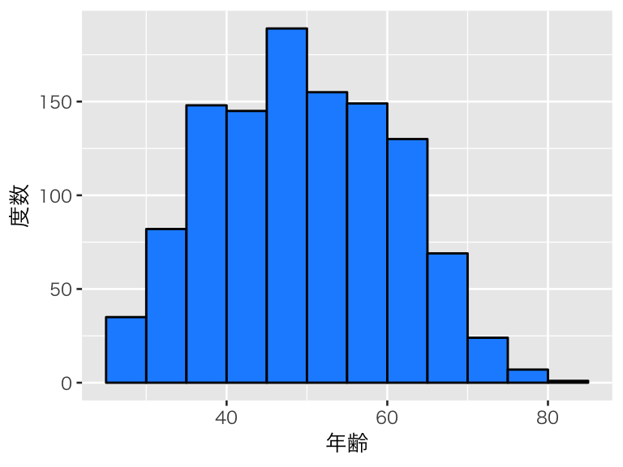

```r
hist_age <- ggplot(HR09, aes(x = age)) +
  geom_histogram(binwidth = 5, boundary = 0,
                 color = "black", fill = "dodgerblue") +
  labs(x = "年齢", y = "度数")
print(hist_age)
```

記述統計をいくつか計算してみよう。まず、`summary()` を使ってみる。

```r
summary(HR09$age)
```

```
##    Min. 1st Qu.  Median    Mean 3rd Qu.    Max.    NA's
##    25.0    41.0    50.0    50.1    59.0    85.0       5
```

最小値が25、最大値が85なので、範囲についてはヒストグラムで確認したものと一致する。 また、中央値が50.0、平均値が50.1なので、データの中心は50付近である。これもヒストグラムで確認したとおりである。 標準偏差も計算してみよう。

```r
sd(HR09$age, na.rm = TRUE)
```

```
## [1] 11.23061
```

### 2.

2. 2009年 (year == 2009) について、得票率 (voteshare) を五数で要約しなさい。また、得票率の箱ひげ図 (boxplot) を政党 (party_jpn) 別に描き、どのようなことがわかるか説明しなさい。

五数を求める。

```r
vs_5num <- with(HR09, fivenum(voteshare))
names(vs_5num) <- c("最小値", "第1四分位数", "中央値", "第3四分位数", "最大値")
vs_5num
```

```
##      最小値 第1四分位数      中央値 第3四分位数      最大値
##         0.1         2.4        30.0        47.3        95.3
```

得票率を政党別に箱ひげ図にして確認する。

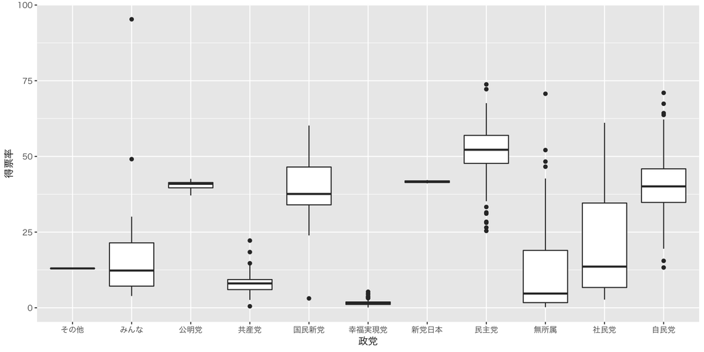

```r
vs_box1 <- ggplot(HR09, aes(x = party_jpn, y = voteshare)) +
  geom_boxplot() +
  labs(x = "政党", y = "得票率")
print(vs_box1)
```

図を見やすくするために、`reorder()` を使って得票率の中央値順に整列させる。

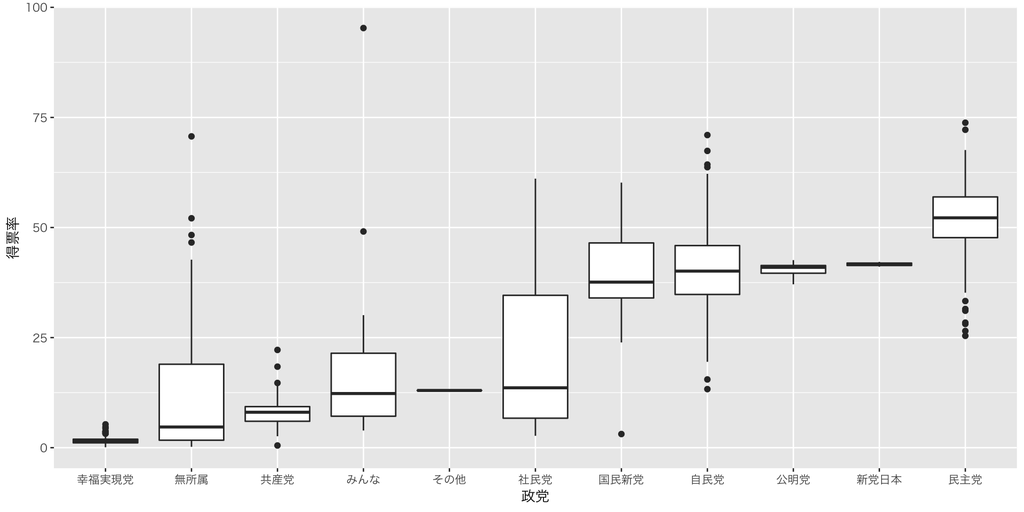

```r
vs_box2 <- ggplot(HR09, aes(x = reorder(party_jpn, X = voteshare, FUN = median),
                            y = voteshare)) +
  geom_boxplot() +
  labs(x = "政党", y = "得票率")
print(vs_box2)
```

この箱ひげ図から、政党によって得票率の分布に違いがあることがわかる。2009年の衆院選では、民主党候補の得票率が全体的に高く、その四分位範囲の全体が、選挙における最大のライバルである自民党の四分位範囲より上にずれていることがわかる。みんなの党や社民党、あるいは無所属の候補者の得票率は全体的に低い。

また、各政党内での得票率の分布を見ると、新党日本、公明党、共産党、幸福実現党は、政党内での得票率にばらつきがほとんどない。（ただし、ばらつきが小さい理由は政党ごとに異なる。理由は何だろうか？各自考えてみるように）。反対に、社民党では得票率のばらつきが大きく、同じ政党であっても得票率が非常に高い候補者と非常に低い候補者がいたことがわかる。

### 3.

まず、voteshare とexpm （expえでもよい）の相関係数を求めてみる。

```r
with(HR09, cor(voteshare, expm))
```

```
## [1] NA
```

NAになってしまう。これは、expm（選挙費用 [百万円]）に欠測（欠損）値があるためだ。そこで、`na.omit()` で欠測がない観測だけを抜き出す。このとき、他の変数に欠測があっても、voteshareとexpm（またはexp）が観測されているものは残したいので、まず `select()` で2変数のみ残してから `na.omit()` を使う。

```r
HR09_2var <- HR09 %>%
  select(voteshare, expm) %>%
  na.omit()
```

元のデータフレームHR09 と、欠測を取り除いたHR09_2varの観測数を比べてみよう。

```r
nrow(HR09) - nrow(HR09_2var)
```

```
## [1] 15
```

15の観測が除外されたことがわかる。念の為、HR09でexpmの値がいくつ欠けていたか確かめよう。

```r
sum(is.na(HR09$expm))
```

```
## [1] 15
```

HR09のexpmには15個の欠測があったことがわかる。HR09_2var は、これらの欠測を除外していることが確認できる。

HR09_2var を使い、あらためて相関係数を求めよう。

```r
with(HR09_2var, cor(voteshare, expm))
```

```
## [1] 0.6915177
```

相関係数は約0.69 で、正の相関がありそうである。

次に、散布図を描いて、2変数の関係を確かめてみよう。

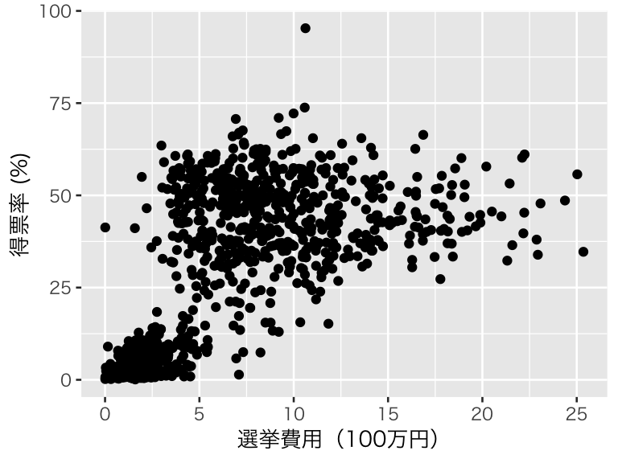

```r
scat <- ggplot(HR09_2var, aes(x = expm, y = voteshare)) +
  geom_point() +
  labs(x = "選挙費用（100万円）", y = "得票率 (%)")
print(scat)
```

確かに、正の相関がありそうに見える。つまり、選挙費用が大きいほど、得票率が高いという関係がありそうだ。

この関係の強さを確かめるために、回帰直線を散布図に当てはめてみよう。

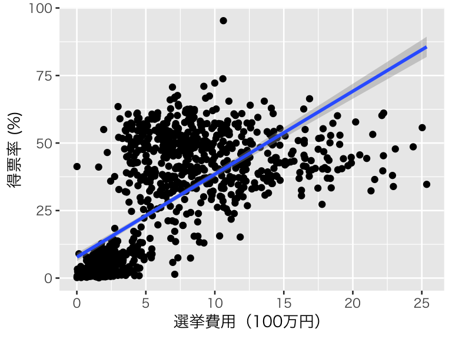

```r
scat_ols <- scat + geom_smooth(method = "lm")
print(scat_ols)
```

右上がりの直線が当てはめられた。ここから、やはり2変数の間には正の相関がありそうである。

最後に、得票率を結果変数（応答変数）、選挙費用を説明変数として、回帰係数を推定してみよう。すなわち、
$$\mbox{得票率}_i = \alpha + \beta \mbox{選挙費用}_i + \epsilon_i$$
という関係を想定し、$\alpha$ と $\beta$ を推定してみよう。

```r
fit <- lm(voteshare ~ expm, data = HR09_2var)
arm::display(fit)
```

```
## lm(formula = voteshare ~ expm, data = HR09_2var)
##             coef.est coef.se
## (Intercept) 7.74     0.76
## expm        3.07     0.10
## ---
## n = 1124, k = 2
## residual sd = 16.04, R-Squared = 0.48
```

この結果から、得票率の予測値は、次の式で表せる。
$$\widehat{\mbox{得票率}} = 7.74 + 3.07 \mbox{選挙費用}$$
すなわち、選挙費用が1単位増加するごとに、得票率は3.07単位増加することが期待される。ここで、選挙費用の測定単位は100万円、得票率の測定単位はパーセントだから、選挙費用が100万増えるごとに、得票率は平均すると3.07パーセントポイント増加するということである。

選挙費用が得票率に影響を与えるという関係は、このデータ（標本）からたまたま得られた結果だろうか。それとも、偶然ではなく、母集団についても成り立つ関係だろうか。有意水準5パーセントで検定してみよう。

ここでは、以下の仮説を検証する。

- 帰無仮説：$\beta = 0$
- 対立仮説：$\beta \neq 0$

$\beta$ の点推定値 $\hat{\beta} = 3.07 \neq 0$ である。しかし、問題は、$\beta \neq 0$ と言えるかである。 $p$値を使って検定しよう。$p$値は、回帰分析の結果に`summary()` を使うと確認できる。

```r
summary(fit)
```

```
##
## Call:
## lm(formula = voteshare ~ expm, data = HR09_2var)
##
## Residuals:
##     Min      1Q  Median      3Q     Max
## -50.916 -11.253  -6.228  12.228  54.937
##
## Coefficients:
##             Estimate Std. Error t value Pr(>|t|)
## (Intercept)  7.73521    0.75660   10.22   <2e-16
## expm         3.07172    0.09579   32.07   <2e-16
##
## Residual standard error: 16.04 on 1122 degrees of freedom
## Multiple R-squared:  0.4782, Adjusted R-squared:  0.4777
## F-statistic:  1028 on 1 and 1122 DF,  p-value: < 2.2e-16
```

expmの$p$値（Pr(>|t|) の列にある値）は、2e-16 $= 2\times 10^{-16} \approx 0 < 0.05$ である。したがって、帰無仮説を棄却する。すなわち、$\beta \neq 0$であり、選挙費用は得票率に影響を与える。

## 問2: 練習問題 3.9.1（教科書 pp.157–159）

必要なデータセットをダウンロードする。

```r
download.file(url = "http://qss.princeton.press/student-files/MEASUREMENT/gayreshaped.csv",
              destfile = "data/gayreshaped.csv")
download.file(url = "http://qss.princeton.press/student-files/MEASUREMENT/ccap2012.csv",
              destfile = "data/ccap2012.csv")
```

二つのデータセットを読み込み、それぞれ GAY, CCAPという名前のデータフレームにする。

```r
GAY <- read_csv("data/gayreshaped.csv")
CCAP <- read_csv("data/ccap2012.csv")
```

データの中身を確認する。

```r
glimpse(GAY)
```

```
## Observations: 11,948
## Variables: 6
## $ study     <int> 1, 1, 1, 1, 1, 1, 1, 1, 1, 1, 1, 1, 2, 2, 2, 2, 1, 2...
## $ treatment <chr> "No Contact", "No Contact", "No Contact", "No Contac...
## $ therm1    <int> 91, 72, 69, 51, 50, 99, 3, 56, 63, 50, 50, 84, 2, 91...
## $ therm2    <int> 91, 72, 69, 51, 48, 99, 3, 56, 63, 54, 47, 84, 6, 90...
## $ therm3    <int> NA, NA, NA, NA, NA, NA, NA, NA, NA, NA, NA, NA, 0, 1...
## $ therm4    <int> NA, NA, NA, NA, NA, NA, NA, NA, NA, NA, NA, NA, 6, 9...
```

```r
glimpse(CCAP)
```

```
## Observations: 43,998
## Variables: 3
## $ X1       <int> 1, 2, 3, 4, 5, 6, 7, 8, 9, 10, 11, 12, 13, 14, 15, 16...
## $ caseid   <int> 328, 324, 100, 584, 63, 461, 81, 735, 565, 16, 705, 4...
## $ gaytherm <int> 50, 95, 16, 50, 58, 100, 93, NA, 72, 71, 96, 50, 59, ...
```

データは正しく読み込めたようである。

この後の分析のため、研究1と研究2を別々のデータフレームにする。

```r
Study1 <- filter(GAY, study == 1)
Study2 <- filter(GAY, study == 2)
```

### 1.

研究1のコントロールグループについて、第1波と第2波の感情温度の相関を調べる。

```r
Study1 %>%
  filter(treatment == "No Contact") %>%
  with(cor(therm1, therm2, use = "complete.obs"))
```

```
## [1] 0.9975817
```

感情温度の相関はほぼ1であり、非常に強い正の相関がある。これは、第1波（第2波）の感情温度がわかれば、ほぼ確実に第2波（第1波）の感情温度を言い当てられるということを意味している。

散布図も作って確かめてみよう。

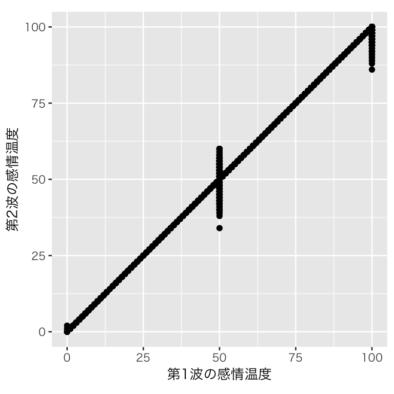

```r
scat_therms <- Study1 %>%
  filter(treatment == "No Contact") %>%
  ggplot(aes(x = therm1, y = therm2)) +
    geom_point() +
    labs(x = "第1波の感情温度", y = "第2波の感情温度") +
    coord_fixed()  # 縦横比を1対1にする
print(scat_therms)
```

ほとんどの観測値が45度線上に乗っており、不自然なデータであることがわかる。

### 2.

研究2のコントロールグループについて、すべての波での感情温度の相関を調べる。 まず、必要な部分のみを含むデータフレームを作る。

```r
GAY2_ctrl <- Study2 %>%
  filter(treatment == "No Contact") %>%
  select(starts_with("therm"))  # "therm" から始まる変数のみ残す
```

相関係数を求める。

```r
cor(GAY2_ctrl, use = "pairwise.complete.obs")
```

```
##           therm1    therm2    therm3    therm4
## therm1 1.0000000 0.9734449 0.9594085 0.9709017
## therm2 0.9734449 1.0000000 0.9308287 0.9436621
## therm3 0.9594085 0.9308287 1.0000000 0.9343249
## therm4 0.9709017 0.9436621 0.9343249 1.0000000
```

どの二つの波を比べても、相関係数が0.93以上だり、強い正の相関がある。つまり、いずれかの波で感情温度が高い回答者は他の波でも感情温度が高く、いずれかの波で感情温度が低い回答者は他の波でも感情温度が低い。

散布図も作ってみよう。複数の組み合わせがあるときは、**ggplot2**と**GGally** パッケージの `GGally::ggpairs()` を使うのが便利である。

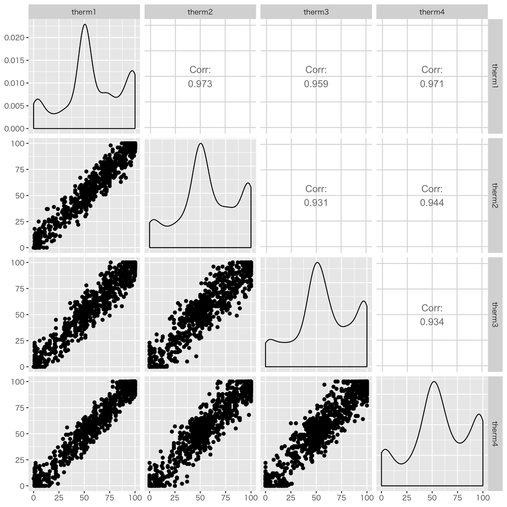

```r
## GGallyをインストール済みでない場合はまずインストールする
# install.packages("GGally", dependencies = TRUE)
scat_pairs <- GGally::ggpairs(GAY2_ctrl)
print(scat_pairs)
```

このように、各ペアの散布図だけでなく、各ペアの相関係数（したがって、相関係数を別に求めなくて済む）と、各変数の分布（ヒストグラムの確率密度を滑らかに描いたもの）が表示される。 この図から、研究1ほどではないものの、散布図の点が右上がりの直線のすぐ近くに固まっていることが読み取れる。

### 3.

まず、三つの散布図に共通する部分だけ書く。

```r
scat_base <- ggplot(GAY2_ctrl, aes(x = therm1)) +
  xlab("第1波の感情温度") +
  coord_fixed()
```

第1波と第2波を比べるための散布図を描く。

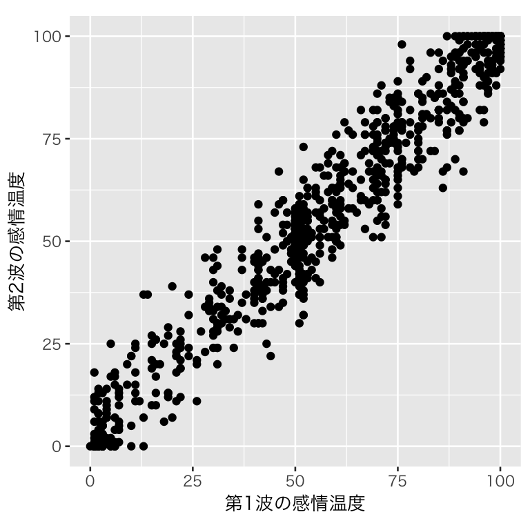

```r
scat_w2 <- scat_base +
  geom_point(aes(y = therm2)) +
  ylab("第2波の感情温度")
print(scat_w2)
```

目立った外れ値は見当たらない。

第1波と第3波を比べるための散布図を描く。

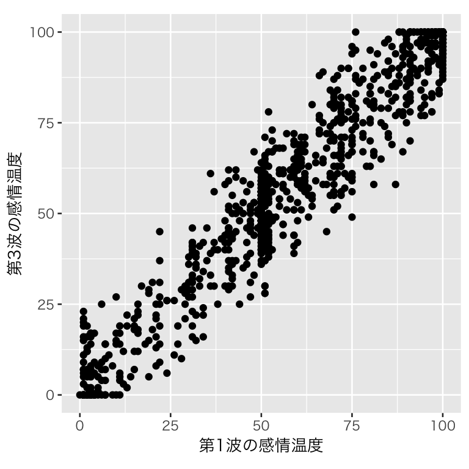

```r
scat_w3 <- scat_base +
  geom_point(aes(y = therm3)) +
  ylab("第3波の感情温度")
print(scat_w3)
```

目立った外れ値は見当たらない。

第1波と第4波を比べるための散布図を描く。

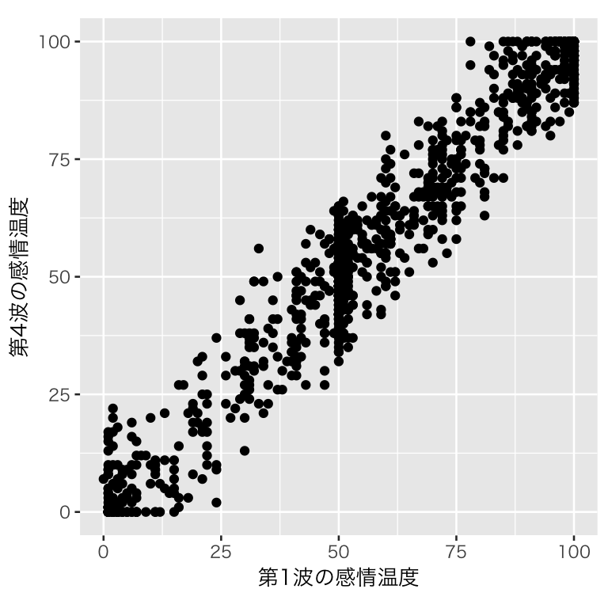

```r
scat_w4 <- scat_base +
  geom_point(aes(y = therm4)) +
  ylab("第4波の感情温度")
print(scat_w4)
```

やはり、目立った外れ値は見当たらない。

全体的にみて、かなり不自然なデータ（これだけで必ずしも嘘だとは断定できないが）であることがわかる。

### 4.

まず、2012年CCAPの感情温度のヒストグラムを作る。

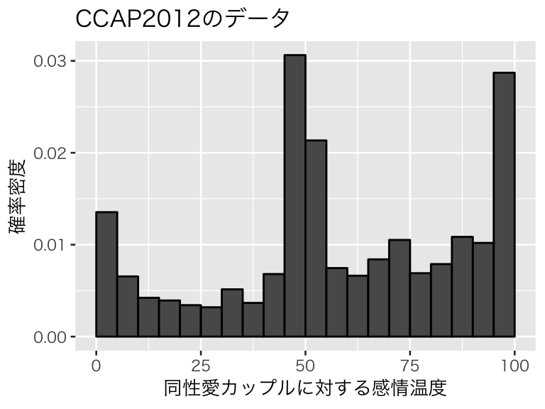

```r
hist_ccap <- ggplot(CCAP, aes(x = gaytherm, y = ..density..)) +
  geom_histogram(binwidth = 5, boundary = 0, color = "black") +
  labs(x = "同性愛カップルに対する感情温度", y = "確率密度",
       title = "CCAP2012のデータ")
print(hist_ccap)
```

研究1の第1波の感情温度のヒストグラムを作る。

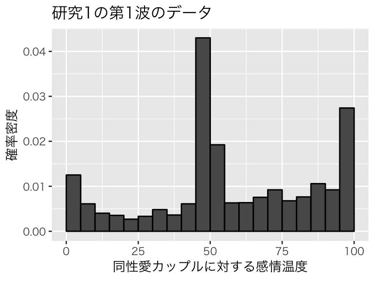

```r
hist_s1 <- Study1 %>%
  ggplot(aes(x = therm1, y = ..density..)) +
  geom_histogram(binwidth = 5, boundary = 0, color = "black") +
  labs(x = "同性愛カップルに対する感情温度", y = "確率密度",
       title = "研究1の第1波のデータ")
print(hist_s1)
```

研究2の第1波の感情温度のヒストグラムを作る。

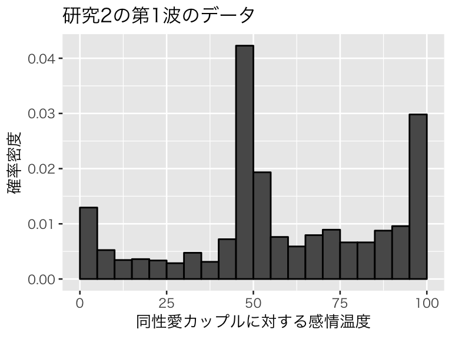

```r
hist_s2 <- Study2 %>%
  ggplot(aes(x = therm1, y = ..density..)) +
  geom_histogram(binwidth = 5, boundary = 0, color = "black") +
  labs(x = "同性愛カップルに対する感情温度", y = "確率密度",
       title = "研究2の第1波のデータ")
print(hist_s2)
```

三つのヒストグラムが非常によく似ていることがわかる。

欠測（欠損）について検討する。 CCAPの感情温度の欠測率を計算する。

```r
mean(is.na(CCAP$gaytherm))
```

```
## [1] 0.07038956
```

欠測率は、約7パーセントである。

同様に、研究1の第1波の欠測率を計算する。

```r
mean(is.na(Study1$therm1))
```

```
## [1] 0
```

研究1の第1波に欠測は記録されていない。

研究2の第1波の欠測率を計算する。

```r
mean(is.na(Study2$therm1))
```

```
## [1] 0
```

研究2の第1波にも欠測は記録されていない。

### 5.

研究1と研究2のそれぞれをCCAPと比較するためのQQプロットを作る。まず、`qqplot()`で描画に必要な値を計算する。このとき、`plotit = FALSE` を指定すると、図を作らず、計算だけしてくれる。その後、`as_data_frame()` で得られた値をデータフレームに変更し、`ggplot()`で図を描く。

まず、研究1をCCAPと比較する。

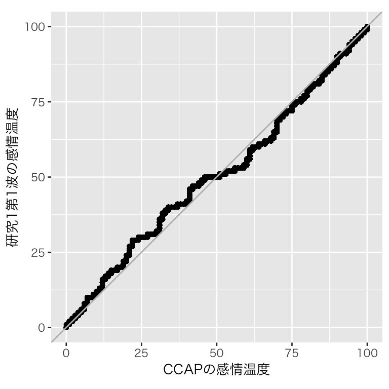

```r
qq_s1 <- qqplot(CCAP$gaytherm, Study1$therm1, plot.it = FALSE) %>%
  as_data_frame() %>%
  ggplot(aes(x = x, y = y)) +
    geom_point(pch = 16) +
    geom_abline(intercept = 0, slope = 1, color = "gray") +
    coord_fixed() +
    labs(x = "CCAPの感情温度", y = "研究1第1波の感情温度")
print(qq_s1)
```

45度線のすぐ近くに点が集まっており、二つの分布がよく似ていることがわかる。

同様に、研究2をCCAPと比較する。

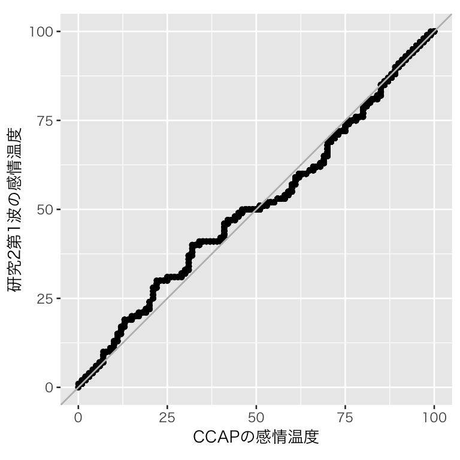

```r
qq_s2 <- qqplot(CCAP$gaytherm, Study2$therm1, plot.it = FALSE) %>%
  as_data_frame() %>%
  ggplot(aes(x = x, y = y)) +
    geom_point(pch = 16) +
    geom_abline(intercept = 0, slope = 1, color = "gray") +
    coord_fixed() +
    labs(x = "CCAPの感情温度", y = "研究2第1波の感情温度")
print(qq_s2)
```

やはり45度線のすぐ近くに点が集まっており、二つの分布がよく似ていることがわかる。

授業の内容に戻る